# hpgltools examples using the fission dataset

atb abelew@gmail.com

2016-08-17

# Example hpgltool usage with a real data set (fission)

This document aims to provide further examples in how to use the hpgltools.

Note to self, the header has rmarkdown::pdf_document instead of html_document or html_vignette because it gets some bullcrap error ‘margins too large’…

## Setting up

Here are the commands I invoke to get ready to play with new data, including everything required to install hpgltools, the software it uses, and the fission data.

```r
## These first 4 lines are not needed once hpgltools is installed.
## source("http://bioconductor.org/biocLite.R")
## biocLite("devtools")
## library(devtools)
## install_github("elsayed-lab/hpgltools")
library(hpgltools)
require.auto("fission")
```

```
## [1] 0
```

```r
library(fission)
data(fission)
```

## Data import

All the work I do in Dr. El-Sayed’s lab makes some pretty hard assumptions about how data is stored. As a result, to use the fission data set I will do a little bit of shenanigans to match it to the expected format. Now that I have played a little with fission, I think its format is quite nice and am likely to have my experiment class instead be a SummarizedExperiment.

```r
## Extract the meta data from the fission dataset
meta <- as.data.frame(fission@colData)
## Make conditions and batches
meta$condition <- paste(meta$strain, meta$minute, sep=".")
meta$batch <- meta$replicate
meta$sample.id <- rownames(meta)
## Grab the count data
fission_data <- fission@assays$data$counts
## This will make an experiment superclass called 'expt' and it contains
## an ExpressionSet along with any arbitrary additional information one might want to include.
## Along the way it writes a Rdata file which is by default called 'expt.Rdata'
fission_expt <- create_expt(meta, count_dataframe=fission_data)
```

```
## Bringing together the count matrix and gene information.
```

## Normalizing and exploring data

There are lots of toys we have learned to use to play with with raw data and explore stuff like batch effects or non-canonical distributions or skewed counts. hpgltools provides some functionality to make this process easier. The graphs shown below and many more are generated with the wrapper ‘graph_metrics()’ but that takes away the chance to explain the graphs as I generate them.

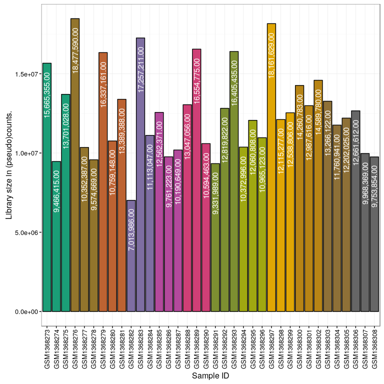

```r
## First make a bar plot of the library sizes in the experiment.
## Notice that the colors were auto-chosen by create_expt() and they should
## be maintained throughout this process
fis_libsize <- plot_libsize(fission_expt)
fis_libsize
```

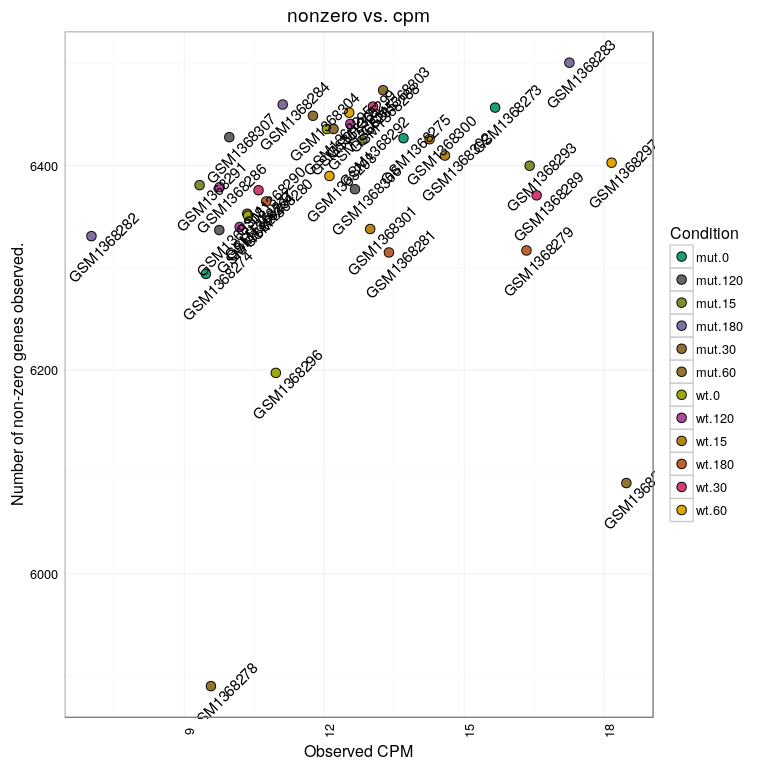

```r
## Here we see that the wild type replicate 3 sample for 15 minutes has fewer non-zero genes than all its friends.
fis_nonzero <- plot_nonzero(fission_expt, labels="boring", title="nonzero vs. cpm")
fis_nonzero
```

### An initial pca plot

In most cases, raw data does not cluster very well, lets see if that is also true for the fission experiment. Assuming it doesn’t, lets normalize the data using the defaults (cpm, quantile, log2) and try again.

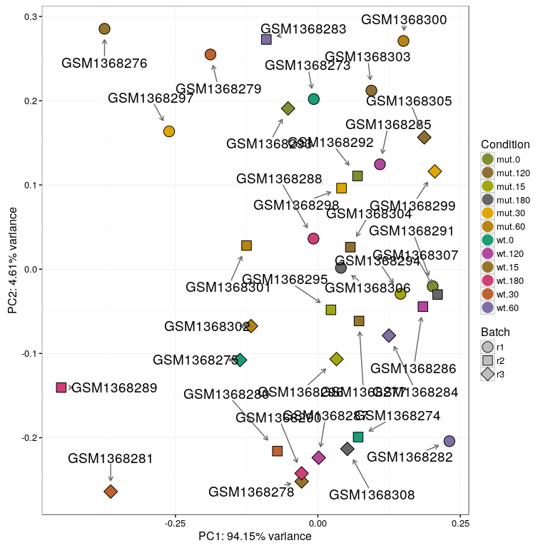

```r
## Something in this is causing a build loop on travis...

## I am no longer certain that code is maintained, what remains from it I might pull in to my own.
## require.auto("kokrah/cbcbSEQ")  ## Install Kwame's cbcbSEQ
## Unsurprisingly, the raw data doesn't cluster well at all...
fis_rawpca <- plot_pca(fission_expt, expt_labels=fission_expt$condition)
fis_rawpca$plot
```

```r
## So, normalize the data
norm_expt <- normalize_expt(fission_expt, transform="log2", norm="quant", convert="cpm")
```

```
## This function will replace the expt$expressionset slot with:
```

```
## log2(cpm(quant(data)))
```

```
## It backs up the current data into a slot named:
##  expt$backup_expressionset. It will also save copies of each step along the way
##  in expt$normalized with the corresponding libsizes. Keep the libsizes in mind
##  when invoking limma.  The appropriate libsize is the non-log(cpm(normalized)).
##  This is most likely kept at:
##  'new_expt$normalized$intermediate_counts$normalization$libsizes'
##  A copy of this may also be found at:
##  new_expt$best_libsize
```

```
## Filter is false, this should likely be set to something, good
##  choices include cbcb, kofa, pofa (anything but FALSE).  If you want this to
##  stay FALSE, keep in mind that if other normalizations are performed, then the
##  resulting libsizes are likely to be strange (potentially negative!)
```

```
## Not correcting the count-data for batch effects.  If batch is
##  included in EdgerR/limma's model, then this is probably wise; but in extreme
##  batch effects this is a good parameter to play with.
```

```
## Step 1: not doing count filtering.
```

```
## Step 2: normalizing the data with quant.
```

```
## Step 3: converting the data with cpm.
```

```
## Step 4: transforming the data with log2.
```

```
## transform_counts: Found 22981 values equal to 0, adding 1 to the matrix.
```

```
## Performing batch correction at step 5.
```

```
## Step 5: not doing batch correction.
```

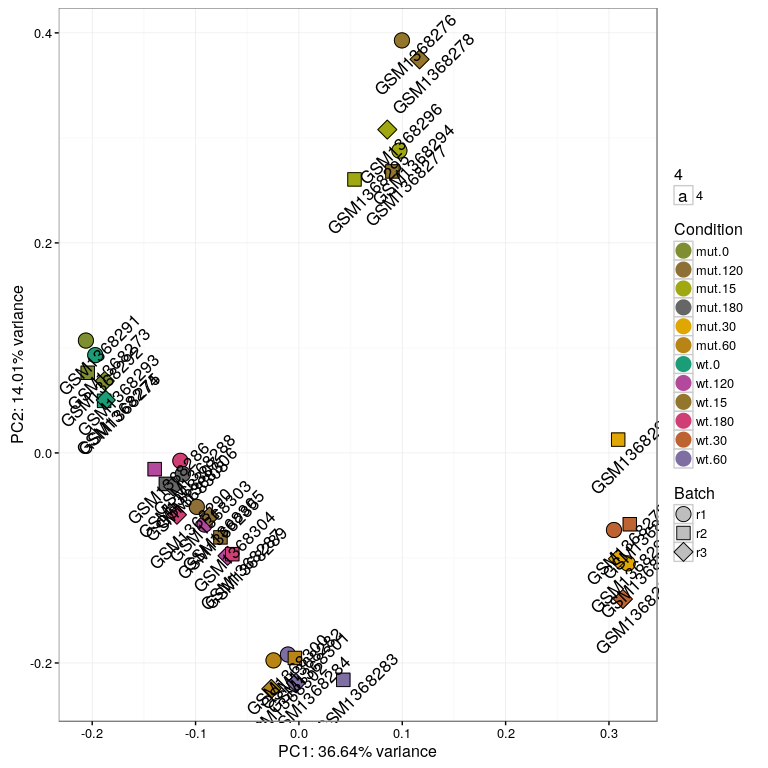

```r
## And try the pca again
fis_normpca <- plot_pca(norm_expt, plot_labels="normal", title="normalized pca")
fis_normpca$plot
```

```r
normbatch_expt <- normalize_expt(fission_expt, transform="log2", norm="quant", convert="cpm", batch="sva")
```

```
## This function will replace the expt$expressionset slot with:
```

```
## log2(sva(cpm(quant(data))))
```

```
## It backs up the current data into a slot named:
##  expt$backup_expressionset. It will also save copies of each step along the way
##  in expt$normalized with the corresponding libsizes. Keep the libsizes in mind
##  when invoking limma.  The appropriate libsize is the non-log(cpm(normalized)).
##  This is most likely kept at:
##  'new_expt$normalized$intermediate_counts$normalization$libsizes'
##  A copy of this may also be found at:
##  new_expt$best_libsize
```

```
## Filter is false, this should likely be set to something, good
##  choices include cbcb, kofa, pofa (anything but FALSE).  If you want this to
##  stay FALSE, keep in mind that if other normalizations are performed, then the
##  resulting libsizes are likely to be strange (potentially negative!)
```

```
## Step 1: not doing count filtering.
```

```
## Step 2: normalizing the data with quant.
```

```
## Step 3: converting the data with cpm.
```

```
## Step 4: transforming the data with log2.
```

```
## transform_counts: Found 22981 values equal to 0, adding 1 to the matrix.
```

```
## Performing batch correction at step 5.
```

```
## Step 5: doing batch correction with sva.
```

```
## Note to self:  If you get an error like 'x contains missing values'; I think this means that the data has too many 0's and needs to have a better low-count filter applied.
```

```
## batch_counts: Before batch correction, 24696 entries 0<x<1.
```

```
## batch_counts: Before batch correction, 22981 entries are >= 0.
```

```
## batch_counts: Using sva::fsva for batch correction.
```

```
## Number of significant surrogate variables is:  5
## Iteration (out of 5 ):1  2  3  4  5
```

```
## The number of elements which are < 0 after batch correction is: 9534
```

```
## The variable low_to_zero sets whether to change <0 values to 0 and is: FALSE
```

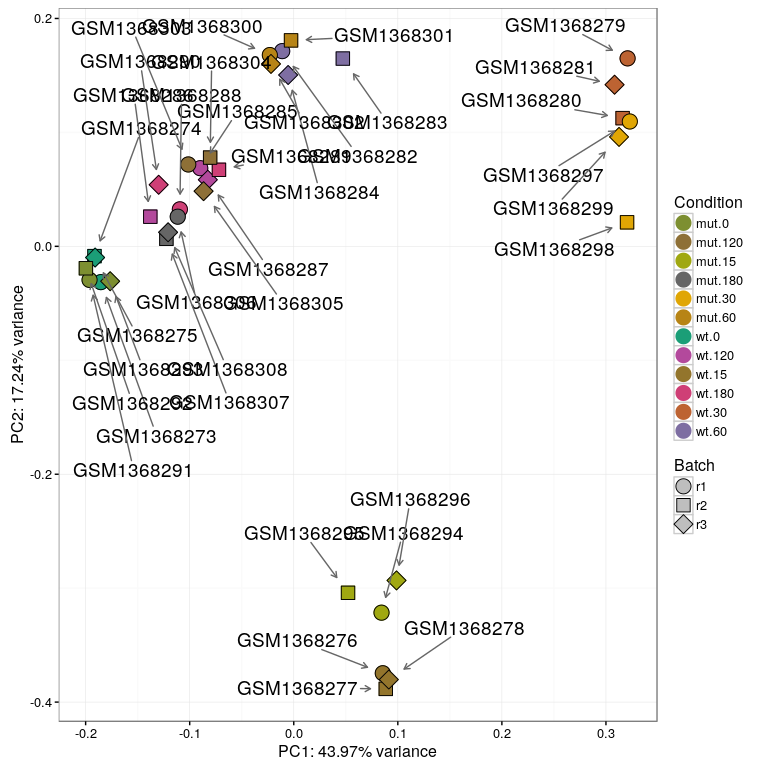

```r
fis_normbatchpca <- plot_pca(normbatch_expt, title="Normalized PCA with batch effect correction.")
fis_normbatchpca$plot
```

```
## The more shallow the curves in these plots, the more genes responsible for this principle component.
```

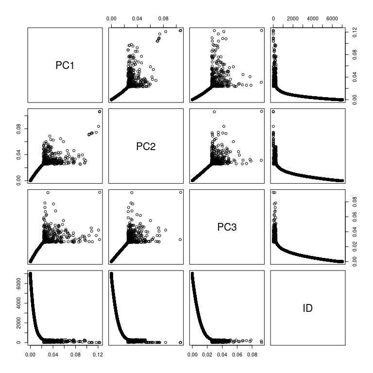

```
## [1] "PC1: 36.64% variance"
## [1] "PC2: 14.01% variance"
```

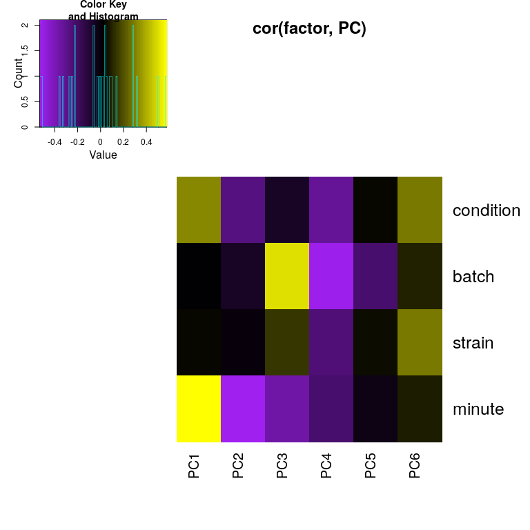

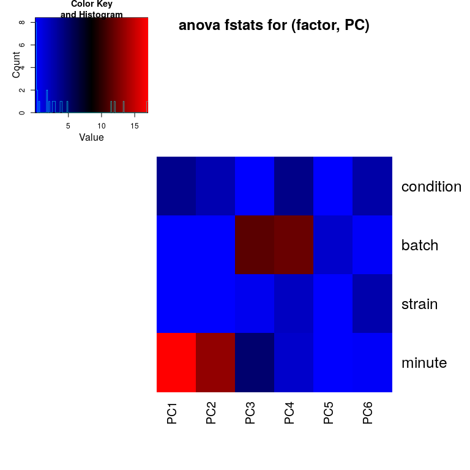

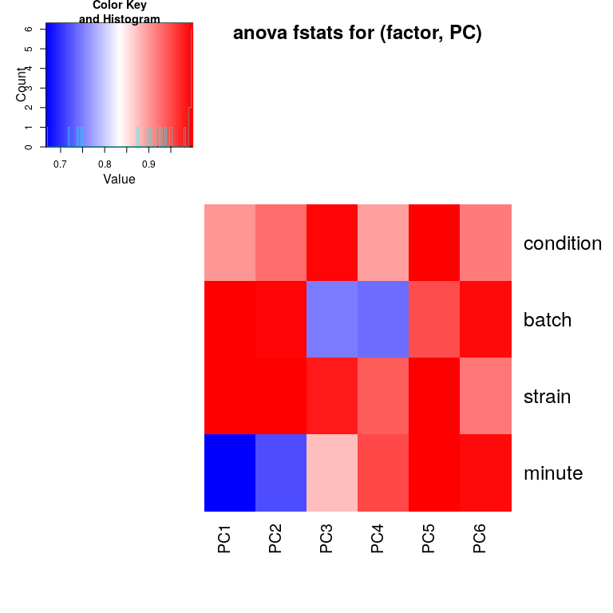

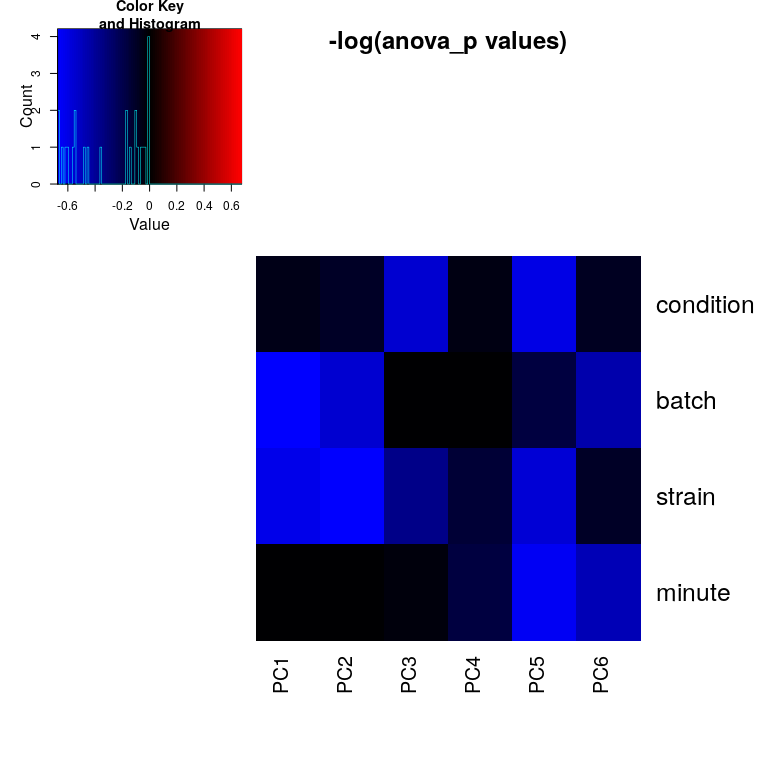

```r
## ok, that caused the 0, 60, 15, and 30 minute samples to cluster nicely
## the 120 and 180 minute samples are still a bit tight

## pca_information provides some more information about the call to
## fast.svd that went into making the pca plot
fis_info <- pca_information(norm_expt, expt_factors=c("condition","batch","strain","minute"), num_components=6)
```